# MIDI-MT - Application Configuration

MIDI-MT Documentation in English

## Basic configuration

- Main settings items
- Module configuration
- Configuring application settings and behavior from the Start dialog
- Configuration files
- Managing audio sessions of running applications
- Setting up Adobe Premier PRO
- Setting up an audio interface for sound control

Basic application settings can be made from the “Start” dialog; alternatively, you can edit the configuration file and make the necessary changes. You can edit in any text editor that supports the `Json` file format. More details about the file format can be found in the section “Configuration files”.

#### Let’s look at the main settings:

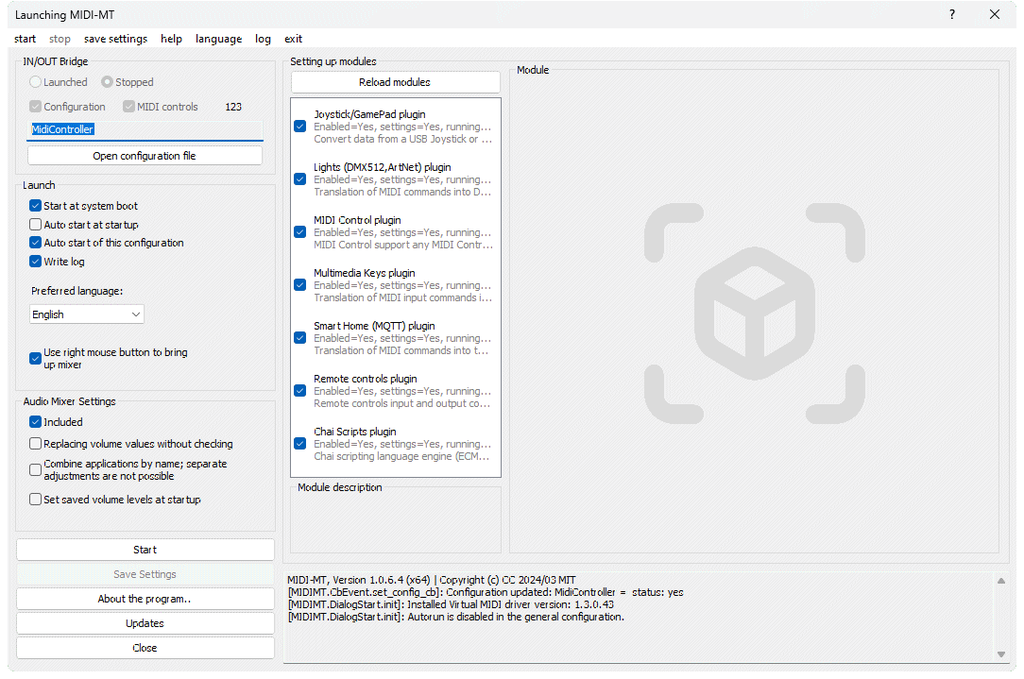

#### Configuring application settings and behavior from the Start dialog

In the “**Launch**” group, parameters related to application autostart are adjusted:

- The checked item “**Start at system boot**” ensures that the application starts when the operating system starts.
- If the “**Auto start on startup**” item is enabled, it will automatically launch the MIDI translator of the application (hereinafter referred to as the bridge) if the file configuration is marked as ready for automatic launch.
- “**Auto start loaded configuration**” will allow you to automatically start the MIDI translator with this configuration when loading the application.
- The “**Record log**” option will allow you to analyze the behavior of both the application and devices connected through it.
- The “**Preferred language**” selection includes `27` available localization options for different languages. You can find a complete list of supported languages on this page.

#### Setting up an audio interface for sound control

You can control audio sessions of running applications either from `MIDI Control Surface` or from the built-in “**Audio Panel**”. To control audio sessions from `MIDI Controllers`, there is no need to call the “**Audio Panel**”. The panel is only needed to configure audio using the mouse, or to visualize the status of current audio sessions.

Learn more about managing audio sessions of running applications.

All selected options in the launch window are saved automatically, except for the “**Auto start loaded configuration**” option. To save it, as well as to save the settings of modules (plugins), you must use the “**Save settings**” button. In the future, these settings will be applied automatically.

#### Module configuration

All information about setting up modules is located in a common configuration file. It is also possible to strictly override the settings of a specific module by placing a settings file of the same name with the module with a `.json` extension in the same directory. An example is shown in the Configuration Files section.

- Module for interaction with MIDI devices
- Module for interaction with Joystick/Gamepad
- Remote control module
- Control module for “Smart Home devices”
- Light control module
- “Multimedia keys” module